# HW 13 - Local Adaptation of Ohia (Mixed Model)

Keanu Rochette

2025-04-26

## Load libraries

```r
# Data manipulation and visualization
library(tidyverse)
library(here)
library(janitor)
library(patchwork)

# Data analysis/statistics
library(car) #ANOVA
library(ggResidpanel) #residual panel
library(ggeffects)
library(effects) #dependency for ggeffects
library(MuMIn)
library(gam)
library(lme4)
library(sjPlot)
library(lmerTest)
library(performance)
library(mgcv)
```

## Load data

```r
ohia <- read_csv(here("HW13", "data", "ohia_merged.csv"))
ohia <- clean_names(ohia)
```

## Question 1

### Drought, population and height

1. Using the seedlings that were harvested after the press drought treatment, analyze how seedling height varies among treatments and populations. Specifically, set up models to test whether populations differ in height, whether press drought treatment affects height and whether populations differ in how press drought affects height.

```r
ohia_harvested <- ohia %>% filter(fate == "harvest")
```

```r
#whether populations differ in height
mod_pop <- lmer(log10(height) ~ population + (1|block), data = ohia_harvested )
```

```r
#whether the press drought treatment affects height
mod_drought<- lmer(log10(height) ~ drought + (1|block), data = ohia_harvested )
```

```r
# whether populations differ in how press drought affects height
mod_popxdrought<- lmer(log10(height) ~ drought + (1|drought:population) + (1|block), data = ohia_harvested )
```

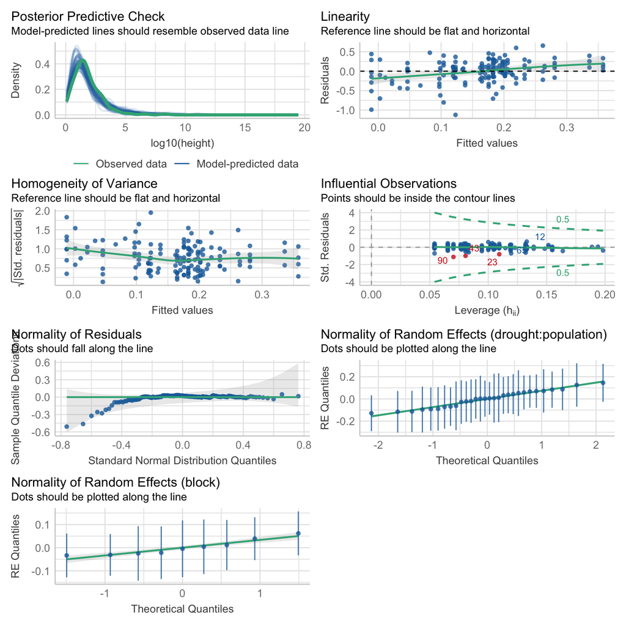

```r
# i checked my models with the code below
check_model(mod_popxdrought)
```

```r
Anova(mod_pop, type = "2")
```

```
## Analysis of Deviance Table (Type II Wald chisquare tests)
##
## Response: log10(height)
##             Chisq Df Pr(>Chisq)
## population 33.426 15   0.004096 **
## ---
## Signif. codes:  0 '***' 0.001 '**' 0.01 '*' 0.05 '.' 0.1 ' ' 1
```

```r
Anova(mod_drought, type = "2")
```

```
## Analysis of Deviance Table (Type II Wald chisquare tests)
##
## Response: log10(height)
##          Chisq Df Pr(>Chisq)
## drought 0.1063  1     0.7444
```

```r
Anova(mod_popxdrought, type = "2")
```

```
## Analysis of Deviance Table (Type II Wald chisquare tests)
##
## Response: log10(height)
##         Chisq Df Pr(>Chisq)
## drought 8e-04  1     0.9771
```

#### Interpretation

- Population affects height significantly (p < 0.05)
- Drought doesn’t affects height significantly (p = 0.7)
- There is no significant difference in how the population affects the effects of droughts on Ohia height (p = 0.98)

### Historical rainfall and height

2. Next, set up models to test whether historical rainfall at a site predicts the height of seedlings, and whether historical rainfall at a site predicts the effect of press drought on height.

```r
# historical rainfall at a site predicts the height of seedlings
mod_marxpop <- lmer(log10(height) ~ mar + (1|block) + (1|mar:population), data = ohia_harvested)
```

```r
# historical rainfall at a site predicts the effect of press drought on height.
mod_marxpopxdrought<- lmer(log10(height) ~ mar * drought + (1|block)+ (1|mar:population),
                           data = ohia_harvested)
```

```r
Anova(mod_marxpop, type = "2")
```

```
## Analysis of Deviance Table (Type II Wald chisquare tests)
##
## Response: log10(height)
##     Chisq Df Pr(>Chisq)
## mar 0.819  1     0.3655
```

```r
ranova(mod_marxpop)
```

```
## ANOVA-like table for random-effects: Single term deletions
##
## Model:
## log10(height) ~ mar + (1 | block) + (1 | mar:population)
##                      npar  logLik    AIC    LRT Df Pr(>Chisq)
## <none>                  5 -46.895 103.79
## (1 | block)             4 -47.850 103.70 1.9085  1   0.167133
## (1 | mar:population)    4 -50.828 109.66 7.8652  1   0.005039 **
## ---
## Signif. codes:  0 '***' 0.001 '**' 0.01 '*' 0.05 '.' 0.1 ' ' 1
```

```r
Anova(mod_marxpopxdrought, type = "3")
```

```
## Analysis of Deviance Table (Type III Wald chisquare tests)
##
## Response: log10(height)
##              Chisq Df Pr(>Chisq)
## (Intercept) 4.0812  1    0.04336 *
## mar         0.6546  1    0.41848
## drought     0.0093  1    0.92332
## mar:drought 0.0076  1    0.93035
## ---
## Signif. codes:  0 '***' 0.001 '**' 0.01 '*' 0.05 '.' 0.1 ' ' 1
```

```r
ranova(mod_marxpopxdrought)
```

```
## ANOVA-like table for random-effects: Single term deletions
##
## Model:
## log10(height) ~ mar + drought + (1 | block) + (1 | mar:population) + mar:drought
##                      npar  logLik    AIC    LRT Df Pr(>Chisq)
## <none>                  7 -56.019 126.04
## (1 | block)             6 -56.918 125.84 1.7985  1   0.179892
## (1 | mar:population)    6 -59.828 131.66 7.6188  1   0.005776 **
## ---
## Signif. codes:  0 '***' 0.001 '**' 0.01 '*' 0.05 '.' 0.1 ' ' 1
```

#### Interpretation

- Historical rainfall at in a population does not affect the height of seedlings significantly.
- Historical rainfall at in a population does not affect the effect of press drought on height significantly

### Historical evapotranspiration

3. Finally, set up models to test whether historical evapotranspiration at a site predicts the height of seedlings, and whether historical evapotranspiration at a site predicts the effect of press drought on height.

```r
# historical evapotranspiration at a site predicts the height of seedlings
mod_metxpop <- lmer(log10(height) ~ met + (1|block) + (1|met:population), data = ohia_harvested)
```

```r
# historical evapotranspiration at a site predicts the effect of press drought on height
mod_metxpopxdrought<- lmer(log10(height) ~ met * drought + (1|block)+ (1|met:population),
                           data = ohia_harvested)
```

```r
Anova(mod_metxpop, type = "2")
```

```
## Analysis of Deviance Table (Type II Wald chisquare tests)
##
## Response: log10(height)
##      Chisq Df Pr(>Chisq)
## met 1.3732  1     0.2413
```

```r
Anova(mod_metxpopxdrought, type = "3")
```

```
## Analysis of Deviance Table (Type III Wald chisquare tests)
##
## Response: log10(height)
##              Chisq Df Pr(>Chisq)
## (Intercept) 5.2020  1    0.02256 *
## met         2.0903  1    0.14823
## drought     0.7236  1    0.39495
## met:drought 0.8864  1    0.34647
## ---
## Signif. codes:  0 '***' 0.001 '**' 0.01 '*' 0.05 '.' 0.1 ' ' 1
```

## Question 2

Using the seedlings that were fated to be harvested after the press drought treatment, analyze how survival during the press drought is affected by the various potential predictors.

### Population, Drought and Mortability

1. set up models to test whether populations vary in probability of mortality (i.e., the response column DEAD), whether the press drought treatment affects mean mortality, and whether populations vary in how mortality is affected by the press drought treatment.

```r
# populations vary in probability of mortality
glmm_pop <- glmer(dead ~ population + (1| block), data= ohia_harvested, family = "binomial")
```

```r
# press drought treatment affects mean mortality
glmm_drought <- glmer(dead ~ drought + (1| block), data= ohia_harvested, family = "binomial")
```

```r
# whether populations vary in how mortality is affected by the press drought treatment
glmm_popxdrought <- glmer(dead ~ drought+ (1+drought|population) + (1| block), data= ohia_harvested, family = "binomial")
```

```r
Anova(glmm_pop, type= "2")
```

```
## Analysis of Deviance Table (Type II Wald chisquare tests)
##
## Response: dead
##             Chisq Df Pr(>Chisq)
## population 27.669 15    0.02373 *
## ---
## Signif. codes:  0 '***' 0.001 '**' 0.01 '*' 0.05 '.' 0.1 ' ' 1
```

```r
Anova(glmm_drought, type= "2")
```

```
## Analysis of Deviance Table (Type II Wald chisquare tests)
##
## Response: dead
##          Chisq Df Pr(>Chisq)
## drought 21.009  1  4.571e-06 ***
## ---
## Signif. codes:  0 '***' 0.001 '**' 0.01 '*' 0.05 '.' 0.1 ' ' 1
```

```r
Anova(glmm_popxdrought, type= "2")
```

```
## Analysis of Deviance Table (Type II Wald chisquare tests)
##
## Response: dead
##          Chisq Df Pr(>Chisq)
## drought 16.814  1  4.122e-05 ***
## ---
## Signif. codes:  0 '***' 0.001 '**' 0.01 '*' 0.05 '.' 0.1 ' ' 1
```

```r
anova(glmm_popxdrought, glmm_pop, glmm_drought)
```

```
## Data: ohia_harvested
## Models:
## glmm_drought: dead ~ drought + (1 | block)
## glmm_popxdrought: dead ~ drought + (1 + drought | population) + (1 | block)
## glmm_pop: dead ~ population + (1 | block)
##                  npar    AIC    BIC  logLik deviance  Chisq Df Pr(>Chisq)
## glmm_drought        3 525.56 537.89 -259.78   519.56
## glmm_popxdrought    6 525.36 550.03 -256.68   513.36 6.1933  3     0.1026
## glmm_pop           17 544.27 614.16 -255.13   510.27 3.0962 11     0.9894
```

#### Interpretation

- populations vary significantly in probability of mortality (p = 0.02 < 0.05)
- press drought treatment affects mortality significantly (p < 0.05)
- the effect of drought treatment on mortality of seedlings is not effected by population variations (chi square p > 0.05)

### Historical rainfall and mortality

2. set up models to test whether historical rainfall at a site predicts mortality, and whether historical rainfall at a site predicts the effect of press drought on mortality.

```r
# historical rainfall at a site predicts mortality
glmm_marxpop <- glmer(dead ~ mar+ (1+mar|population) + (1| block), data = ohia_harvested, family = "binomial")
```

```r
# whether historical rainfall at a site predicts the effect of press drought on mortality
glmm_marxdroughtxpop <- glmer(dead ~ mar + (1+mar|drought)+ (1+mar|population) + (1| block), data = ohia_harvested, family = "binomial")
```

```r
Anova(glmm_marxpop, type = "2")
```

```
## Analysis of Deviance Table (Type II Wald chisquare tests)
##
## Response: dead
##      Chisq Df Pr(>Chisq)
## mar 10.012  1   0.001555 **
## ---
## Signif. codes:  0 '***' 0.001 '**' 0.01 '*' 0.05 '.' 0.1 ' ' 1
```

```r
Anova(glmm_marxdroughtxpop, type = "2")
```

```
## Analysis of Deviance Table (Type II Wald chisquare tests)
##
## Response: dead
##      Chisq Df Pr(>Chisq)
## mar 8.5885  1   0.003383 **
## ---
## Signif. codes:  0 '***' 0.001 '**' 0.01 '*' 0.05 '.' 0.1 ' ' 1
```

```r
anova(glmm_marxpop, glmm_marxdroughtxpop)
```

```
## Data: ohia_harvested
## Models:
## glmm_marxpop: dead ~ mar + (1 + mar | population) + (1 | block)
## glmm_marxdroughtxpop: dead ~ mar + (1 + mar | drought) + (1 + mar | population) + (1 | block)
##                      npar    AIC    BIC  logLik deviance  Chisq Df Pr(>Chisq)
## glmm_marxpop            6 538.23 562.90 -263.12   526.23
## glmm_marxdroughtxpop    9 527.10 564.11 -254.55   509.10 17.125  3  0.0006661
##
## glmm_marxpop
## glmm_marxdroughtxpop ***
## ---
## Signif. codes:  0 '***' 0.001 '**' 0.01 '*' 0.05 '.' 0.1 ' ' 1
```

#### Interpretation

- historical rainfall at a site significantly impact mortality (p<0.05)
- historical rainfall at a site significantly impact the effect of drought on mortality (p <0.05 in the anova() )

### Historical evapotranspiration, population, drought, and mortality

3. set up models to test whether historical evapotranspiration at a site predicts mortality, and whether historical evapotranspiration at a site predicts the effect of press drought on mortality.

```r
# historical evapotranspiration at a site predicts mortality
glmm_met <- glmer(dead ~ met + (1+met |population) + (1| block), data = ohia_harvested, family = "binomial")
```

```r
# historical evapotranspiration at a site predicts the effect of press drought on mortality
glmm_metxdrought <- glmer(dead ~ met*drought +(1+met|population) +
                            (1| block),
                          data = ohia_harvested, family = "binomial")
```

```r
Anova(glmm_met, type = "2")
```

```
## Analysis of Deviance Table (Type II Wald chisquare tests)
##
## Response: dead
##      Chisq Df Pr(>Chisq)
## met 0.3627  1      0.547
```

```r
Anova(glmm_metxdrought, type = "2")
```

```
## Analysis of Deviance Table (Type II Wald chisquare tests)
##
## Response: dead
##                  Chisq Df Pr(>Chisq)
## met             1.6805  1     0.1949
## drought     11172.3422  1  < 2.2e-16 ***
## met:drought    35.9171  1  2.059e-09 ***
## ---
## Signif. codes:  0 '***' 0.001 '**' 0.01 '*' 0.05 '.' 0.1 ' ' 1
```

```r
anova(glmm_met, glmm_metxdrought)
```

```
## Data: ohia_harvested
## Models:
## glmm_met: dead ~ met + (1 + met | population) + (1 | block)
## glmm_metxdrought: dead ~ met * drought + (1 + met | population) + (1 | block)
##                  npar    AIC    BIC  logLik deviance  Chisq Df Pr(>Chisq)
## glmm_met            6 543.92 568.58 -265.96   531.92
## glmm_metxdrought    8 523.52 556.41 -253.76   507.52 24.395  2  5.042e-06 ***
## ---
## Signif. codes:  0 '***' 0.001 '**' 0.01 '*' 0.05 '.' 0.1 ' ' 1
```

#### Interpretation

- Evapotranspiration by itself does not significantly impact the mortality.
- Drought significantly impacts the mortality of Ohia and there is a significant interaction between evapotranspiration and drought (p < 0.05 in anova())

## Question 3

Using the seedlings that were fated for the terminal drought experiment (i.e., the seedlings that were not harvested), analyze how longevity during terminal drought is affected by the various potential predictors.

```r
ohia_term <- ohia %>%  filter(fate != "harvested")
```

### Longevity, drought and population

1. set up models to test whether populations vary in longevity, whether the press drought treatment affects longevity, and whether populations vary in how longevity is affected by the press drought treatment.

```r
#populations vary in longevity
long_pop <- lmer(log10(longevity) ~ population + (1| block), data = ohia_term)
```

```r
#drought treatment affects longevity
long_drought <- lmer(log10(longevity) ~ drought + (1| block), data = ohia_term)
```

```r
#  populations vary in how longevity is affected by the press drought treatment
long_popxdrought <- lmer(log10(longevity) ~ population*drought + (1| block), data = ohia_term)
```

```r
Anova(long_pop,type = "2")
```

```
## Analysis of Deviance Table (Type II Wald chisquare tests)
##
## Response: log10(longevity)
##             Chisq Df Pr(>Chisq)
## population 74.938 14   2.43e-10 ***
## ---
## Signif. codes:  0 '***' 0.001 '**' 0.01 '*' 0.05 '.' 0.1 ' ' 1
```

```r
Anova(long_drought,type = "2")
```

```
## Analysis of Deviance Table (Type II Wald chisquare tests)
##
## Response: log10(longevity)
##         Chisq Df Pr(>Chisq)
## drought 1.747  1     0.1862
```

```r
Anova(long_popxdrought,type = "2")
```

```
## Analysis of Deviance Table (Type II Wald chisquare tests)
##
## Response: log10(longevity)
##                      Chisq Df Pr(>Chisq)
## population         72.8740 14  5.795e-10 ***
## drought             0.4491  1     0.5028
## population:drought 19.5031 13     0.1083
## ---
## Signif. codes:  0 '***' 0.001 '**' 0.01 '*' 0.05 '.' 0.1 ' ' 1
```

```r
anova(long_pop, long_drought, long_popxdrought)
```

```
## Data: ohia_term
## Models:
## long_drought: log10(longevity) ~ drought + (1 | block)
## long_pop: log10(longevity) ~ population + (1 | block)
## long_popxdrought: log10(longevity) ~ population * drought + (1 | block)
##                  npar     AIC     BIC logLik deviance  Chisq Df Pr(>Chisq)
## long_drought        4 -31.258 -18.810 19.629  -39.258
## long_pop           17 -71.243 -18.339 52.622 -105.243 65.985 13  4.364e-09 ***
## long_popxdrought   31 -63.940  32.531 62.970 -125.940 20.697 14     0.1096
## ---
## Signif. codes:  0 '***' 0.001 '**' 0.01 '*' 0.05 '.' 0.1 ' ' 1
```

#### Interpretation

- The population significantly affects the longevity of the ohia seedling (p < 0.05)
- Drought treatment did not impact the longevity of the seedlings. There was no difference between the control and the drought treatments
- Drought treatment did not affect the longevity of the seedling between population

### Longevity and rainfall

2. set up models to test whether historical rainfall at a site predicts longevity, and whether historical rainfall at a site predicts the effect of press drought on longevity.

```r
# historical rainfall at a site predicts longevity
long_mar <- lmer(log10(longevity) ~ mar + (1+mar|population) + (1| block), data = ohia_term)
```

```r
# historical rainfall at a site predicts the effect of press drought on longevity
long_marxdrought <- lmer(log10(longevity) ~ mar*drought + (1+mar|population) + (1| block), data = ohia_term)
```

```r
Anova(long_mar, type = "2")
```

```
## Analysis of Deviance Table (Type II Wald chisquare tests)
##
## Response: log10(longevity)
##      Chisq Df Pr(>Chisq)
## mar 7.0098  1   0.008107 **
## ---
## Signif. codes:  0 '***' 0.001 '**' 0.01 '*' 0.05 '.' 0.1 ' ' 1
```

```r
Anova(long_marxdrought, type = "2")
```

```
## Analysis of Deviance Table (Type II Wald chisquare tests)
##
## Response: log10(longevity)
##              Chisq Df Pr(>Chisq)
## mar         8.2288  1   0.004123 **
## drought     0.8843  1   0.347021
## mar:drought 4.6769  1   0.030572 *
## ---
## Signif. codes:  0 '***' 0.001 '**' 0.01 '*' 0.05 '.' 0.1 ' ' 1
```

```r
anova(long_mar,long_marxdrought)
```

```
## Data: ohia_term
## Models:
## long_mar: log10(longevity) ~ mar + (1 + mar | population) + (1 | block)
## long_marxdrought: log10(longevity) ~ mar * drought + (1 + mar | population) + (1 | block)
##                  npar     AIC     BIC logLik deviance  Chisq Df Pr(>Chisq)
## long_mar            7 -61.223 -39.439 37.612  -75.223
## long_marxdrought    9 -63.219 -35.211 40.609  -81.219 5.9954  2     0.0499 *
## ---
## Signif. codes:  0 '***' 0.001 '**' 0.01 '*' 0.05 '.' 0.1 ' ' 1
```

#### Interpretation

- Historical rainfall at a site significantly affects longevity of seedlings.
- historical rainfall at a site significant impacted the effect of drought on longevity.

### Longevity and evapotranspiration

3. set up models to test whether historical evapotranspiration at a site predicts longevity, and whether historical evapotranspiration at a site predicts the effect of press drought on longevity. How do you interpret the results?

```r
# historical evapotranspiration at a site predicts longevity
long_met <- lmer(log10(longevity) ~ met + (1+met|population) + (1| block), data = ohia_term)
```

```r
# historical evapotranspiration at a site predicts the effect of press drought on longevity
long_metxdrought <- lmer(log10(longevity) ~ met*drought + (1+met|population) + (1| block), data = ohia_term)
```

```r
Anova(long_met, type = "2")
```

```
## Analysis of Deviance Table (Type II Wald chisquare tests)
##
## Response: log10(longevity)
##      Chisq Df Pr(>Chisq)
## met 5.1836  1     0.0228 *
## ---
## Signif. codes:  0 '***' 0.001 '**' 0.01 '*' 0.05 '.' 0.1 ' ' 1
```

```r
Anova(long_metxdrought, type = "2")
```

```
## Analysis of Deviance Table (Type II Wald chisquare tests)
##
## Response: log10(longevity)
##              Chisq Df Pr(>Chisq)
## met         5.0713  1    0.02433 *
## drought     0.4810  1    0.48799
## met:drought 1.4566  1    0.22748
## ---
## Signif. codes:  0 '***' 0.001 '**' 0.01 '*' 0.05 '.' 0.1 ' ' 1
```

#### Interpretation

- Evapotranspiration at a site significantly affects longevity of seedlings. (p<0.05)
- Evapotranspiration at a site significant did not impacted the effect of drought on longevity (p=0.23).